# Seccion 3.2 : limpieza de datos

# Eliminar datos con na.omit

Esto se hace cuando el dato no nos interesa y no tiene un valor per se. Se trabajará con un scv de ejemplo

```r
data <- read.csv("../data/tema1/missing-data.csv")
data
```

```
##    Income Phone_type   Car_type
## 1   89800    Android     Luxury
## 2   47500    Android Non-Luxury
## 3   45000     iPhone     Luxury
## 4   44700                Luxury
## 5   59500     iPhone     Luxury
## 6      NA    Android Non-Luxury
## 7   63300     iPhone Non-Luxury
## 8   52900    Android     Luxury
## 9   78200    Android     Luxury
## 10 145100     iPhone     Luxury
## 11  88600     iPhone Non-Luxury
## 12  65600     iPhone     Luxury
## 13     NA    Android Non-Luxury
## 14  94600    Android     Luxury
## 15  59400     iPhone     Luxury
## 16  47300     iPhone Non-Luxury
## 17  72100                Luxury
## 18      0     iPhone Non-Luxury
## 19      0    Android     Luxury
## 20  83000     iPhone     Luxury
## 21  64100    Android Non-Luxury
## 22  42100     iPhone Non-Luxury
## 23      0     iPhone     Luxury
## 24  91500     iPhone Non-Luxury
## 25  51200    Android     Luxury
## 26  13800     iPhone Non-Luxury
## 27  47500     iPhone Non-Luxury
```

Note que en general, lo que faltan son NA de strings, entonces una mejor forma de leer el archivo es

```r
data <- read.csv("../data/tema1/missing-data.csv", na.strings = "")
data
```

```
##    Income Phone_type   Car_type
## 1   89800    Android     Luxury
## 2   47500    Android Non-Luxury
## 3   45000     iPhone     Luxury
## 4   44700       <NA>     Luxury
## 5   59500     iPhone     Luxury
## 6      NA    Android Non-Luxury
## 7   63300     iPhone Non-Luxury
## 8   52900    Android     Luxury
## 9   78200    Android     Luxury
## 10 145100     iPhone     Luxury
## 11  88600     iPhone Non-Luxury
## 12  65600     iPhone     Luxury
## 13     NA    Android Non-Luxury
## 14  94600    Android     Luxury
## 15  59400     iPhone     Luxury
## 16  47300     iPhone Non-Luxury
## 17  72100       <NA>     Luxury
## 18      0     iPhone Non-Luxury
## 19      0    Android     Luxury
## 20  83000     iPhone     Luxury
## 21  64100    Android Non-Luxury
## 22  42100     iPhone Non-Luxury
## 23      0     iPhone     Luxury
## 24  91500     iPhone Non-Luxury
## 25  51200    Android     Luxury
## 26  13800     iPhone Non-Luxury
## 27  47500     iPhone Non-Luxury
```

Ya es al menos, se han convertido en NA. ¿Como se limpia?

```r
data.cleaned <- na.omit(data)
data.cleaned
```

```
##    Income Phone_type   Car_type
## 1   89800    Android     Luxury
## 2   47500    Android Non-Luxury
## 3   45000     iPhone     Luxury
## 5   59500     iPhone     Luxury
## 7   63300     iPhone Non-Luxury
## 8   52900    Android     Luxury
## 9   78200    Android     Luxury
## 10 145100     iPhone     Luxury
## 11  88600     iPhone Non-Luxury
## 12  65600     iPhone     Luxury
## 14  94600    Android     Luxury
## 15  59400     iPhone     Luxury
## 16  47300     iPhone Non-Luxury
## 18      0     iPhone Non-Luxury
## 19      0    Android     Luxury
## 20  83000     iPhone     Luxury
## 21  64100    Android Non-Luxury
## 22  42100     iPhone Non-Luxury
## 23      0     iPhone     Luxury
## 24  91500     iPhone Non-Luxury
## 25  51200    Android     Luxury
## 26  13800     iPhone Non-Luxury
## 27  47500     iPhone Non-Luxury
```

Esta fn lo qu eha hecho es eliminar entonces los na del conjunto de datos. Antes, 27 registros ahora; 23

Lo que utiliza na.omit es coger la fn is.na para hacer todo esto.

```r
is.na(data[4,2])
```

```
## [1] TRUE
```

```r
is.na(data$Income)
```

```
##  [1] FALSE FALSE FALSE FALSE FALSE  TRUE FALSE FALSE FALSE FALSE FALSE FALSE
## [13]  TRUE FALSE FALSE FALSE FALSE FALSE FALSE FALSE FALSE FALSE FALSE FALSE
## [25] FALSE FALSE FALSE
```

# Limpieza selectiva de los datos sin valor:

Suponga que solo me interesa eliminar na de la columna de ingresos.

```r
# Na limpios de la vble income
data.income.cleaned <- data[!is.na(data$Income),]
data.income.cleaned
```

```
##    Income Phone_type   Car_type
## 1   89800    Android     Luxury
## 2   47500    Android Non-Luxury
## 3   45000     iPhone     Luxury
## 4   44700       <NA>     Luxury
## 5   59500     iPhone     Luxury
## 7   63300     iPhone Non-Luxury
## 8   52900    Android     Luxury
## 9   78200    Android     Luxury
## 10 145100     iPhone     Luxury
## 11  88600     iPhone Non-Luxury
## 12  65600     iPhone     Luxury
## 14  94600    Android     Luxury
## 15  59400     iPhone     Luxury
## 16  47300     iPhone Non-Luxury
## 17  72100       <NA>     Luxury
## 18      0     iPhone Non-Luxury
## 19      0    Android     Luxury
## 20  83000     iPhone     Luxury
## 21  64100    Android Non-Luxury
## 22  42100     iPhone Non-Luxury
## 23      0     iPhone     Luxury
## 24  91500     iPhone Non-Luxury
## 25  51200    Android     Luxury
## 26  13800     iPhone Non-Luxury
## 27  47500     iPhone Non-Luxury
```

## Complete cases

Esta funcion lo que hace es que asocia una matriz boolean de t y F a las observaciones de los datos(matriz)

```r
# filas completa para un df
complete.cases(data)
```

```
##  [1]  TRUE  TRUE  TRUE FALSE  TRUE FALSE  TRUE  TRUE  TRUE  TRUE  TRUE  TRUE
## [13] FALSE  TRUE  TRUE  TRUE FALSE  TRUE  TRUE  TRUE  TRUE  TRUE  TRUE  TRUE
## [25]  TRUE  TRUE  TRUE
```

Me dice que las obvservaciones 4,6 etc son observaciones con datos faltantes.

```r
data.cleaned.2 <- data[complete.cases(data),]
data.cleaned.2
```

```
##    Income Phone_type   Car_type
## 1   89800    Android     Luxury
## 2   47500    Android Non-Luxury
## 3   45000     iPhone     Luxury
## 5   59500     iPhone     Luxury
## 7   63300     iPhone Non-Luxury
## 8   52900    Android     Luxury
## 9   78200    Android     Luxury
## 10 145100     iPhone     Luxury
## 11  88600     iPhone Non-Luxury
## 12  65600     iPhone     Luxury
## 14  94600    Android     Luxury
## 15  59400     iPhone     Luxury
## 16  47300     iPhone Non-Luxury
## 18      0     iPhone Non-Luxury
## 19      0    Android     Luxury
## 20  83000     iPhone     Luxury
## 21  64100    Android Non-Luxury
## 22  42100     iPhone Non-Luxury
## 23      0     iPhone     Luxury
## 24  91500     iPhone Non-Luxury
## 25  51200    Android     Luxury
## 26  13800     iPhone Non-Luxury
## 27  47500     iPhone Non-Luxury
```

Note que es tambien un filtro para los NA

## Ejercicio 2:

Novierra los ceros en NA. Note que un ingreso cero (0) no necesariamente es un dato. Entonces, esto puede ser un NA.

```r
# Convirtiendo ceros en NA en los datos originales

data$Income[data$Income==0]<- NA
```

# Reemplazo de NA con la media o extraccion aleatoria

```r
data <- read.csv("../data/tema1/missing-data.csv", na.strings = "")
data
```

```
##    Income Phone_type   Car_type
## 1   89800    Android     Luxury
## 2   47500    Android Non-Luxury
## 3   45000     iPhone     Luxury
## 4   44700       <NA>     Luxury
## 5   59500     iPhone     Luxury
## 6      NA    Android Non-Luxury
## 7   63300     iPhone Non-Luxury
## 8   52900    Android     Luxury
## 9   78200    Android     Luxury
## 10 145100     iPhone     Luxury
## 11  88600     iPhone Non-Luxury
## 12  65600     iPhone     Luxury
## 13     NA    Android Non-Luxury
## 14  94600    Android     Luxury
## 15  59400     iPhone     Luxury
## 16  47300     iPhone Non-Luxury
## 17  72100       <NA>     Luxury
## 18      0     iPhone Non-Luxury
## 19      0    Android     Luxury
## 20  83000     iPhone     Luxury
## 21  64100    Android Non-Luxury
## 22  42100     iPhone Non-Luxury
## 23      0     iPhone     Luxury
## 24  91500     iPhone Non-Luxury
## 25  51200    Android     Luxury
## 26  13800     iPhone Non-Luxury
## 27  47500     iPhone Non-Luxury
```

Ifelse <- Si el dato que tengo es un NA entonces reemplacelo con la media.

Si no, dejelo igual

```r
data$Income.mean = ifelse(is.na(data$Income),
                          mean(data$Income, na.rm = TRUE),
                          data$Income)

  data
```

```
##    Income Phone_type   Car_type Income.mean
## 1   89800    Android     Luxury       89800
## 2   47500    Android Non-Luxury       47500
## 3   45000     iPhone     Luxury       45000
## 4   44700       <NA>     Luxury       44700
## 5   59500     iPhone     Luxury       59500
## 6      NA    Android Non-Luxury       57872
## 7   63300     iPhone Non-Luxury       63300
## 8   52900    Android     Luxury       52900
## 9   78200    Android     Luxury       78200
## 10 145100     iPhone     Luxury      145100
## 11  88600     iPhone Non-Luxury       88600
## 12  65600     iPhone     Luxury       65600
## 13     NA    Android Non-Luxury       57872
## 14  94600    Android     Luxury       94600
## 15  59400     iPhone     Luxury       59400
## 16  47300     iPhone Non-Luxury       47300
## 17  72100       <NA>     Luxury       72100
## 18      0     iPhone Non-Luxury           0
## 19      0    Android     Luxury           0
## 20  83000     iPhone     Luxury       83000
## 21  64100    Android Non-Luxury       64100
## 22  42100     iPhone Non-Luxury       42100
## 23      0     iPhone     Luxury           0
## 24  91500     iPhone Non-Luxury       91500
## 25  51200    Android     Luxury       51200
## 26  13800     iPhone Non-Luxury       13800
## 27  47500     iPhone Non-Luxury       47500
```

## Reemplazo aleatorio

```r
rand.impute <- function(x){ # X vector de datos con NA
  missing <- is.na(x) #missing es un vector de tamaño de X con TRUE y FALSE
  n.missing <- sum(missing) #Sumo el numero de TRUE, cuantos valores NA hay
  x.obs <- x[!missing] # valores differtente de NA de X
  imputed <- x
  # Los valores que faltaban, se reemplzada por los valores que si se conocen (MAS)
  imputed[missing]<- sample(x.obs, n.missing,replace = T)
  return(imputed)
}
```

```r
# Una fn para correr rand.impute en cada una de las columnas del dataframe que tengo

random.impute.data.frame <- function(dataframe,cols){

  names <- names(dataframe)
  for (col in cols) {
    name <- paste(names[col], "imputed", sep = ".")
    dataframe[name] = rand.impute(dataframe[,col])

  }
  dataframe
}
```

se sabe que los na son en las columnas 1 y 2 entonces..

```r
require(tidyverse)
data <- read.csv("../data/tema1/missing-data.csv", na.strings = "")
data$Income[data$Income==0] <- NA

data <- random.impute.data.frame(data, c(1,2))
data %>% View()
```

# Evitando duplicaciones de entradas

Suponga lo siguiente

```r
family.salay <- c(40000,60000,50000,80000,60000,70000,60000)
family.size <- c(4,3,2,2,3,4,3)
family.car <- c("Lujo", "compacto", "utilitario", "Lujo", "compacto", "compacto", "compacto")
```

```r
family <- data.frame(family.salay,family.size,family.car)
family
```

```
##   family.salay family.size family.car
## 1        40000           4       Lujo
## 2        60000           3   compacto
## 3        50000           2 utilitario
## 4        80000           2       Lujo
## 5        60000           3   compacto
## 6        70000           4   compacto
## 7        60000           3   compacto
```

Note entonces que a este momento, se tiene un df con obsrevaciones repetidas.

*Funcioin unique()*

```r
family.unique <- unique(family)
family.unique
```

```
##   family.salay family.size family.car
## 1        40000           4       Lujo
## 2        60000           3   compacto
## 3        50000           2 utilitario
## 4        80000           2       Lujo
## 6        70000           4   compacto
```

Tambien, puedo ver si un dato es el duplicado de alguien

```r
duplicated(family)
```

```
## [1] FALSE FALSE FALSE FALSE  TRUE FALSE  TRUE
```

```r
family[duplicated(family),]
```

```
##   family.salay family.size family.car
## 5        60000           3   compacto
## 7        60000           3   compacto
```

Asi se encuentra los valores que son duplicados del data set original

# Reescalado lineal de datos

Como reescalar una vble enntre dos valores, 0-1

```r
require(scales)
students <- read.csv("../data/tema1/data-conversion.csv")
students
```

```
##    Age State Gender Height Income
## 1   23    NJ      F     61   5000
## 2   13    NY      M     55   1000
## 3   36    NJ      M     66   3000
## 4   31    VA      F     64   4000
## 5   58    NY      F     70  30000
## 6   29    TX      F     63  10000
## 7   39    NJ      M     67  50000
## 8   50    VA      M     70  55000
## 9   23    TX      F     61   2000
## 10  36    VA      M     66  20000
```

Vamos a reescalar la varibale income puesto que es necesario entender que la escala de los datos respecto a la edad es diferente.

```r
students$Income.rescaled <- rescale(students$Income)
students
```

```
##    Age State Gender Height Income Income.rescaled
## 1   23    NJ      F     61   5000      0.07407407
## 2   13    NY      M     55   1000      0.00000000
## 3   36    NJ      M     66   3000      0.03703704
## 4   31    VA      F     64   4000      0.05555556
## 5   58    NY      F     70  30000      0.53703704
## 6   29    TX      F     63  10000      0.16666667
## 7   39    NJ      M     67  50000      0.90740741
## 8   50    VA      M     70  55000      1.00000000
## 9   23    TX      F     61   2000      0.01851852
## 10  36    VA      M     66  20000      0.35185185
```

El valor mas pequeño, lo toma como cero.

El valor mas grande, 1.

```r
(students$Income-min(students$Income))/(max(students$Income)-min(students$Income))
```

```
##  [1] 0.07407407 0.00000000 0.03703704 0.05555556 0.53703704 0.16666667
##  [7] 0.90740741 1.00000000 0.01851852 0.35185185
```

Es basicamente lo que hace la funcion rescale.

```r
# reescalado en 0-100

rescale(students$Income, to =c(0,100))
```

```
##  [1]   7.407407   0.000000   3.703704   5.555556  53.703704  16.666667
##  [7]  90.740741 100.000000   1.851852  35.185185
```

## Reescalando un df

```r
# Parametro: dataframe y columnas

rescale.many <- function(dataframe, cols){

  names <- names(dataframe)
  for(col in cols){
    name = paste(names[col], "rescales", sep =".")
    dataframe[name]<- rescale(dataframe[,col])
  }
  cat(paste("hemos reescalado", length(cols),"variable(s)"))
  dataframe
}
```

```r
rescale.many(students, c(1,4))
```

```
## hemos reescalado 2 variable(s)
```

```
##    Age State Gender Height Income Income.rescaled Age.rescales Height.rescales
## 1   23    NJ      F     61   5000      0.07407407    0.2222222       0.4000000
## 2   13    NY      M     55   1000      0.00000000    0.0000000       0.0000000
## 3   36    NJ      M     66   3000      0.03703704    0.5111111       0.7333333
## 4   31    VA      F     64   4000      0.05555556    0.4000000       0.6000000
## 5   58    NY      F     70  30000      0.53703704    1.0000000       1.0000000
## 6   29    TX      F     63  10000      0.16666667    0.3555556       0.5333333
## 7   39    NJ      M     67  50000      0.90740741    0.5777778       0.8000000
## 8   50    VA      M     70  55000      1.00000000    0.8222222       1.0000000
## 9   23    TX      F     61   2000      0.01851852    0.2222222       0.4000000
## 10  36    VA      M     66  20000      0.35185185    0.5111111       0.7333333
```

# Normalizando o estandarizando un dataframe

Vamos a estandarizar el df de boston houses.

```r
housing <- read.csv("../data/tema1/BostonHousing.csv")
housing
```

```
##         CRIM    ZN INDUS CHAS    NOX    RM   AGE     DIS RAD TAX PTRATIO      B
## 1    0.00632  18.0  2.31    0 0.5380 6.575  65.2  4.0900   1 296    15.3 396.90
## 2    0.02731   0.0  7.07    0 0.4690 6.421  78.9  4.9671   2 242    17.8 396.90
## 3    0.02729   0.0  7.07    0 0.4690 7.185  61.1  4.9671   2 242    17.8 392.83
## 4    0.03237   0.0  2.18    0 0.4580 6.998  45.8  6.0622   3 222    18.7 394.63
## 5    0.06905   0.0  2.18    0 0.4580 7.147  54.2  6.0622   3 222    18.7 396.90
## 6    0.02985   0.0  2.18    0 0.4580 6.430  58.7  6.0622   3 222    18.7 394.12
## 7    0.08829  12.5  7.87    0 0.5240 6.012  66.6  5.5605   5 311    15.2 395.60
## 8    0.14455  12.5  7.87    0 0.5240 6.172  96.1  5.9505   5 311    15.2 396.90
## 9    0.21124  12.5  7.87    0 0.5240 5.631 100.0  6.0821   5 311    15.2 386.63
## 10   0.17004  12.5  7.87    0 0.5240 6.004  85.9  6.5921   5 311    15.2 386.71
## 11   0.22489  12.5  7.87    0 0.5240 6.377  94.3  6.3467   5 311    15.2 392.52
## 12   0.11747  12.5  7.87    0 0.5240 6.009  82.9  6.2267   5 311    15.2 396.90
## 13   0.09378  12.5  7.87    0 0.5240 5.889  39.0  5.4509   5 311    15.2 390.50
## 14   0.62976   0.0  8.14    0 0.5380 5.949  61.8  4.7075   4 307    21.0 396.90
```

[output cut: 999 more lines]

```r
housing.z <- scale(housing)
```

Con esto acaba de centrar con la distribucion normal.

Solo funciona SI TODAS LAS VARIABLES DEL DF SON NUMERICAS

Normalizando varias variables de un df:

```r
scale.many = function(dataframe, cols){
  names <- names(dataframe)
  for(col in cols){
    name <- paste(names[col], "z", sep = ".")
    dataframe[name] <- scale(dataframe[,col])
  }
  cat(paste("Hemos normalizado ", length(cols), " variable(s)"))
  dataframe
}
```

```r
housing <- scale.many(housing, c(1, 3, 5:8))
```

```
## Hemos normalizado  6  variable(s)
```

# Categorizando info numerica

```r
students <- read.csv("../data/tema1/data-conversion.csv")
students
```

```
##    Age State Gender Height Income
## 1   23    NJ      F     61   5000
## 2   13    NY      M     55   1000
## 3   36    NJ      M     66   3000
## 4   31    VA      F     64   4000
## 5   58    NY      F     70  30000
## 6   29    TX      F     63  10000
## 7   39    NJ      M     67  50000
## 8   50    VA      M     70  55000
## 9   23    TX      F     61   2000
## 10  36    VA      M     66  20000
```

Suponga que nos interesa analizar el valor de la variable income con una variable categorica que resuma el nuvek de ingresos.

Ej:

income <10.000 <-> ingresos bajos

Vamos entonces a crar un vector de breakpoints para las posibles categorias de la variable income

```r
bp <- c(-Inf, 10000,31000,Inf)
names <- c("Low", "Average", "High")
students$Income.cate <- cut(students$Income, breaks = bp,
                            labels = names)
```

```r
students
```

```
##    Age State Gender Height Income Income.cate
## 1   23    NJ      F     61   5000         Low
## 2   13    NY      M     55   1000         Low
## 3   36    NJ      M     66   3000         Low
## 4   31    VA      F     64   4000         Low
## 5   58    NY      F     70  30000     Average
## 6   29    TX      F     63  10000         Low
## 7   39    NJ      M     67  50000        High
## 8   50    VA      M     70  55000        High
## 9   23    TX      F     61   2000         Low
## 10  36    VA      M     66  20000     Average
```

##Intervalo de corte equitativo

```r
students$Income.cat2 <- cut(students$Income,
                            breaks = 4,
                            labels = c("l1","l2","l3","l4"))
students
```

```
##    Age State Gender Height Income Income.cate Income.cat2
## 1   23    NJ      F     61   5000         Low          l1
## 2   13    NY      M     55   1000         Low          l1
## 3   36    NJ      M     66   3000         Low          l1
## 4   31    VA      F     64   4000         Low          l1
## 5   58    NY      F     70  30000     Average          l3
## 6   29    TX      F     63  10000         Low          l1
## 7   39    NJ      M     67  50000        High          l4
## 8   50    VA      M     70  55000        High          l4
## 9   23    TX      F     61   2000         Low          l1
## 10  36    VA      M     66  20000     Average          l2
```

Aqui R corta automaticamente para tener 4 breaks

# Dummy variables / Variables ficticias

Basicamente lo que quiero hacer es aplicar las metodologias numericas dado una tranfsormacion de categorias.

```r
require(dummies)
students <- read.csv("../data/tema1/data-conversion.csv")
```

```r
students.dummy <- dummy.data.frame(students, sep = ".")
names(students.dummy)
```

```
## [1] "Age"      "State.NJ" "State.NY" "State.TX" "State.VA" "Gender.F" "Gender.M"
## [8] "Height"   "Income"
```

```r
students.dummy %>% view() # Muy parecidoa  regresion
```

```r
dummy(students$State)
```

```
##       C:/Users/jhsga/OneDrive/Escritorio/GitHub/r-course/Scripts smith/Seccion 3-2 Limpieza de datos.RmdNJ
##  [1,]                                                                                                    1
##  [2,]                                                                                                    0
##  [3,]                                                                                                    1
##  [4,]                                                                                                    0
##  [5,]                                                                                                    0
##  [6,]                                                                                                    0
##  [7,]                                                                                                    1
##  [8,]                                                                                                    0
##  [9,]                                                                                                    0
## [10,]                                                                                                    0
##       C:/Users/jhsga/OneDrive/Escritorio/GitHub/r-course/Scripts smith/Seccion 3-2 Limpieza de datos.RmdNY
##  [1,]                                                                                                    0
##  [2,]                                                                                                    1
##  [3,]                                                                                                    0
```

[output cut: 29 more lines]

Tambien puedo especificar a quienes especificamente les quiero aplicar las variables dummies.

```r
dummy.data.frame( students,
                 names =c("State", "Gender"),
                 sep = ".")
```

```
##    Age State.NJ State.NY State.TX State.VA Gender.F Gender.M Height Income
## 1   23        1        0        0        0        1        0     61   5000
## 2   13        0        1        0        0        0        1     55   1000
## 3   36        1        0        0        0        0        1     66   3000
## 4   31        0        0        0        1        1        0     64   4000
## 5   58        0        1        0        0        1        0     70  30000
## 6   29        0        0        1        0        1        0     63  10000
## 7   39        1        0        0        0        0        1     67  50000
## 8   50        0        0        0        1        0        1     70  55000
## 9   23        0        0        1        0        1        0     61   2000
## 10  36        0        0        0        1        0        1     66  20000
```

# Eliminando informacion faltante

Primero se hace un analisis para eliminar NA.

En general uno 1) Borra los datos NA, 2) Borra la variable con NA, 3) Tecnica de rellenado NA

Con un df de house, vamos a trabajar con un df con missing values para practicar.

```r
housing.data <- read.csv("../data/tema1/housing-with-missing-value.csv", header = T, stringsAsFactors = F)
```

Tenemos algunos NA.

```r
summary(housing.data)
```

```
##        X              crim                zn             indus
##  Min.   :  1.0   Min.   : 0.00632   Min.   :  0.00   Min.   : 0.46
##  1st Qu.:127.2   1st Qu.: 0.08205   1st Qu.:  0.00   1st Qu.: 5.19
##  Median :253.5   Median : 0.25651   Median :  0.00   Median : 9.69
##  Mean   :253.5   Mean   : 3.61352   Mean   : 11.36   Mean   :11.14
##  3rd Qu.:379.8   3rd Qu.: 3.67708   3rd Qu.: 12.50   3rd Qu.:18.10
##  Max.   :506.0   Max.   :88.97620   Max.   :100.00   Max.   :27.74
##
##       chas              nox               rm             age
##  Min.   :0.00000   Min.   :0.3850   Min.   :3.561   Min.   :  2.90
##  1st Qu.:0.00000   1st Qu.:0.4490   1st Qu.:5.886   1st Qu.: 45.02
##  Median :0.00000   Median :0.5380   Median :6.208   Median : 77.50
##  Mean   :0.06917   Mean   :0.5547   Mean   :6.285   Mean   : 68.57
##  3rd Qu.:0.00000   3rd Qu.:0.6240   3rd Qu.:6.623   3rd Qu.: 94.08
##  Max.   :1.00000   Max.   :0.8710   Max.   :8.780   Max.   :100.00
##
##       dis              rad              tax           ptratio
##  Min.   : 1.130   Min.   : 1.000   Min.   :187.0   Min.   :12.60
##  1st Qu.: 2.100   1st Qu.: 4.000   1st Qu.:279.0   1st Qu.:17.40
##  Median : 3.207   Median : 5.000   Median :330.0   Median :19.10
##  Mean   : 3.795   Mean   : 9.515   Mean   :408.2   Mean   :18.47
##  3rd Qu.: 5.188   3rd Qu.:24.000   3rd Qu.:666.0   3rd Qu.:20.20
##  Max.   :12.127   Max.   :24.000   Max.   :711.0   Max.   :22.00
##                   NA's   :40                       NA's   :40
##        b              lstat            medv
##  Min.   :  0.32   Min.   : 1.73   Min.   : 5.00
##  1st Qu.:375.38   1st Qu.: 6.95   1st Qu.:17.02
##  Median :391.44   Median :11.36   Median :21.20
##  Mean   :356.67   Mean   :12.65   Mean   :22.53
##  3rd Qu.:396.23   3rd Qu.:16.95   3rd Qu.:25.00
##  Max.   :396.90   Max.   :37.97   Max.   :50.00
##
```

Note que la variable rad, me presenta 40 NA’s.

ptratio tambien tiene 40 NA’s.

Esto ya es un motivo de preocupacion ¿Por que? Pregunra a realizarse.

## Formas para desaparecer estos NA’s

*Primer variante*

```r
housing.data.1<- na.omit(housing.data)
summary(housing.data.1)
```

```
##        X              crim                zn             indus
##  Min.   :  1.0   Min.   : 0.00632   Min.   :  0.00   Min.   : 0.46
##  1st Qu.:120.5   1st Qu.: 0.07373   1st Qu.:  0.00   1st Qu.: 5.13
##  Median :252.0   Median : 0.25356   Median :  0.00   Median : 8.56
##  Mean   :251.4   Mean   : 3.66428   Mean   : 11.79   Mean   :11.03
##  3rd Qu.:381.5   3rd Qu.: 3.69503   3rd Qu.: 15.00   3rd Qu.:18.10
##  Max.   :506.0   Max.   :88.97620   Max.   :100.00   Max.   :27.74
##       chas              nox               rm             age
##  Min.   :0.00000   Min.   :0.3850   Min.   :3.561   Min.   :  2.90
##  1st Qu.:0.00000   1st Qu.:0.4480   1st Qu.:5.886   1st Qu.: 45.25
##  Median :0.00000   Median :0.5380   Median :6.195   Median : 76.70
##  Mean   :0.06729   Mean   :0.5529   Mean   :6.277   Mean   : 68.51
##  3rd Qu.:0.00000   3rd Qu.:0.6240   3rd Qu.:6.630   3rd Qu.: 94.30
##  Max.   :1.00000   Max.   :0.8710   Max.   :8.780   Max.   :100.00
##       dis              rad              tax           ptratio
##  Min.   : 1.130   Min.   : 1.000   Min.   :187.0   Min.   :12.60
##  1st Qu.: 2.083   1st Qu.: 4.000   1st Qu.:278.0   1st Qu.:17.40
##  Median : 3.360   Median : 5.000   Median :330.0   Median :19.10
##  Mean   : 3.861   Mean   : 9.599   Mean   :407.8   Mean   :18.47
##  3rd Qu.: 5.287   3rd Qu.:24.000   3rd Qu.:666.0   3rd Qu.:20.20
##  Max.   :12.127   Max.   :24.000   Max.   :711.0   Max.   :22.00
##        b              lstat            medv
##  Min.   :  0.32   Min.   : 1.73   Min.   : 5.00
##  1st Qu.:374.96   1st Qu.: 6.91   1st Qu.:16.60
##  Median :391.45   Median :11.41   Median :21.10
##  Mean   :357.24   Mean   :12.76   Mean   :22.38
##  3rd Qu.:396.25   3rd Qu.:17.14   3rd Qu.:25.00
##  Max.   :396.90   Max.   :37.97   Max.   :50.00
```

Al analizar cd uno de los dataframe, podria llevar a perdida de informacion.

Esto es algo que ha de evaluarse en la practica.

Esta es la solucion de las mas bestias.

*Opcion 2: Elimino NA pero solo de una columna*

Yo solo quiero eliminar NA de los rad (para el ejemplo)

```r
drop_na <- c("rad") # de las que tienen NA, las que quiero conservar
housing.data.2 <- housing.data[
  complete.cases(housing.data[,!(names(housing.data))%in% drop_na])  ,]
```

Esto ha hecho desaparecer los NA de todas las columnas menos de rad.

```r
summary(housing.data.2)
```

```
##        X              crim                zn             indus
##  Min.   :  1.0   Min.   : 0.00632   Min.   :  0.00   Min.   : 0.46
##  1st Qu.:126.2   1st Qu.: 0.07880   1st Qu.:  0.00   1st Qu.: 5.13
##  Median :254.5   Median : 0.25651   Median :  0.00   Median : 8.56
##  Mean   :253.5   Mean   : 3.73046   Mean   : 11.53   Mean   :11.06
##  3rd Qu.:380.8   3rd Qu.: 3.68939   3rd Qu.: 12.50   3rd Qu.:18.10
##  Max.   :506.0   Max.   :88.97620   Max.   :100.00   Max.   :27.74
##
##       chas              nox               rm             age
##  Min.   :0.00000   Min.   :0.3850   Min.   :3.561   Min.   :  2.90
##  1st Qu.:0.00000   1st Qu.:0.4490   1st Qu.:5.886   1st Qu.: 45.62
##  Median :0.00000   Median :0.5380   Median :6.211   Median : 76.80
##  Mean   :0.06438   Mean   :0.5536   Mean   :6.284   Mean   : 68.72
##  3rd Qu.:0.00000   3rd Qu.:0.6240   3rd Qu.:6.630   3rd Qu.: 94.38
##  Max.   :1.00000   Max.   :0.8710   Max.   :8.780   Max.   :100.00
##
##       dis              rad              tax           ptratio
##  Min.   : 1.130   Min.   : 1.000   Min.   :187.0   Min.   :12.60
##  1st Qu.: 2.091   1st Qu.: 4.000   1st Qu.:279.0   1st Qu.:17.40
##  Median : 3.299   Median : 5.000   Median :330.0   Median :19.10
##  Mean   : 3.824   Mean   : 9.599   Mean   :408.7   Mean   :18.47
##  3rd Qu.: 5.215   3rd Qu.:24.000   3rd Qu.:666.0   3rd Qu.:20.20
##  Max.   :12.127   Max.   :24.000   Max.   :711.0   Max.   :22.00
##                   NA's   :35
##        b              lstat             medv
##  Min.   :  0.32   Min.   : 1.730   Min.   : 5.00
##  1st Qu.:375.24   1st Qu.: 6.923   1st Qu.:16.73
##  Median :391.38   Median :11.235   Median :21.20
##  Mean   :358.05   Mean   :12.662   Mean   :22.53
##  3rd Qu.:396.23   3rd Qu.:17.043   3rd Qu.:25.00
##  Max.   :396.90   Max.   :37.970   Max.   :50.00
##
```

Ya no tenemos NA en el df. Menos en rat

*Eliminando toda la columna del df*

```r
housing.data$rad <- NULL # Esto hace que se me eliminen todas las variables
```

O si quisiera cargarme mas columans…

```r
housing.data <- read.csv("../data/tema1/housing-with-missing-value.csv", header = T, stringsAsFactors = F)

drops <- c("rad", "ptratio")
housins.data.3 <- housing.data[,!names(housing.data)%in% drops]
```

```r
summary(housins.data.3)
```

```
##        X              crim                zn             indus
##  Min.   :  1.0   Min.   : 0.00632   Min.   :  0.00   Min.   : 0.46
##  1st Qu.:127.2   1st Qu.: 0.08205   1st Qu.:  0.00   1st Qu.: 5.19
##  Median :253.5   Median : 0.25651   Median :  0.00   Median : 9.69
##  Mean   :253.5   Mean   : 3.61352   Mean   : 11.36   Mean   :11.14
##  3rd Qu.:379.8   3rd Qu.: 3.67708   3rd Qu.: 12.50   3rd Qu.:18.10
##  Max.   :506.0   Max.   :88.97620   Max.   :100.00   Max.   :27.74
##       chas              nox               rm             age
##  Min.   :0.00000   Min.   :0.3850   Min.   :3.561   Min.   :  2.90
##  1st Qu.:0.00000   1st Qu.:0.4490   1st Qu.:5.886   1st Qu.: 45.02
##  Median :0.00000   Median :0.5380   Median :6.208   Median : 77.50
##  Mean   :0.06917   Mean   :0.5547   Mean   :6.285   Mean   : 68.57
##  3rd Qu.:0.00000   3rd Qu.:0.6240   3rd Qu.:6.623   3rd Qu.: 94.08
##  Max.   :1.00000   Max.   :0.8710   Max.   :8.780   Max.   :100.00
##       dis              tax              b              lstat
##  Min.   : 1.130   Min.   :187.0   Min.   :  0.32   Min.   : 1.73
##  1st Qu.: 2.100   1st Qu.:279.0   1st Qu.:375.38   1st Qu.: 6.95
##  Median : 3.207   Median :330.0   Median :391.44   Median :11.36
##  Mean   : 3.795   Mean   :408.2   Mean   :356.67   Mean   :12.65
##  3rd Qu.: 5.188   3rd Qu.:666.0   3rd Qu.:396.23   3rd Qu.:16.95
##  Max.   :12.127   Max.   :711.0   Max.   :396.90   Max.   :37.97
##       medv
##  Min.   : 5.00
##  1st Qu.:17.02
##  Median :21.20
##  Mean   :22.53
##  3rd Qu.:25.00
##  Max.   :50.00
```

Note que este ahora tiene menos las columnas que selecioné.

# Formas de completar informacion

```r
#install.packages("Hmisc")
require(Hmisc)
```

La idea es que, yo quiero reemplazar los NA’s por otros valores conocidos

```r
housing.data <- read.csv("../data/tema1/housing-with-missing-value.csv", header = T, stringsAsFactors = F)

housing.data.copy1 <- housing.data

housing.data.copy1$ptratio <- impute(housing.data.copy1$ptratio, mean)
housing.data.copy1$rat <- impute(housing.data.copy1$rat, mean)
```

Aqui simplemente con la funcion impute, se le calcula el promedio y se reemplza en los espacios na.

```r
housing.data.copy1 %>% summary()
```

```
##
##  40 values imputed to 18.4676
```

```
##        X              crim                zn             indus
##  Min.   :  1.0   Min.   : 0.00632   Min.   :  0.00   Min.   : 0.46
##  1st Qu.:127.2   1st Qu.: 0.08205   1st Qu.:  0.00   1st Qu.: 5.19
##  Median :253.5   Median : 0.25651   Median :  0.00   Median : 9.69
##  Mean   :253.5   Mean   : 3.61352   Mean   : 11.36   Mean   :11.14
##  3rd Qu.:379.8   3rd Qu.: 3.67708   3rd Qu.: 12.50   3rd Qu.:18.10
##  Max.   :506.0   Max.   :88.97620   Max.   :100.00   Max.   :27.74
##
##       chas              nox               rm             age
##  Min.   :0.00000   Min.   :0.3850   Min.   :3.561   Min.   :  2.90
##  1st Qu.:0.00000   1st Qu.:0.4490   1st Qu.:5.886   1st Qu.: 45.02
##  Median :0.00000   Median :0.5380   Median :6.208   Median : 77.50
##  Mean   :0.06917   Mean   :0.5547   Mean   :6.285   Mean   : 68.57
##  3rd Qu.:0.00000   3rd Qu.:0.6240   3rd Qu.:6.623   3rd Qu.: 94.08
##  Max.   :1.00000   Max.   :0.8710   Max.   :8.780   Max.   :100.00
##
##       dis              rad              tax           ptratio
##  Min.   : 1.130   Min.   : 1.000   Min.   :187.0   Min.   :12.60
##  1st Qu.: 2.100   1st Qu.: 4.000   1st Qu.:279.0   1st Qu.:17.40
##  Median : 3.207   Median : 5.000   Median :330.0   Median :18.60
##  Mean   : 3.795   Mean   : 9.515   Mean   :408.2   Mean   :18.47
##  3rd Qu.: 5.188   3rd Qu.:24.000   3rd Qu.:666.0   3rd Qu.:20.20
##  Max.   :12.127   Max.   :24.000   Max.   :711.0   Max.   :22.00
##                   NA's   :40
##        b              lstat            medv
##  Min.   :  0.32   Min.   : 1.73   Min.   : 5.00
##  1st Qu.:375.38   1st Qu.: 6.95   1st Qu.:17.02
##  Median :391.44   Median :11.36   Median :21.20
##  Mean   :356.67   Mean   :12.65   Mean   :22.53
##  3rd Qu.:396.23   3rd Qu.:16.95   3rd Qu.:25.00
##  Max.   :396.90   Max.   :37.97   Max.   :50.00
##
```

```r
housing.data.copy2 <- housing.data

housing.data.copy2$ptratio <- impute(housing.data.copy2$ptratio, median)
housing.data.copy2$rat <- impute(housing.data.copy2$rat, median)
housing.data.copy2 %>% summary()
```

```
##
##  40 values imputed to 19.1
```

```
##        X              crim                zn             indus
##  Min.   :  1.0   Min.   : 0.00632   Min.   :  0.00   Min.   : 0.46
##  1st Qu.:127.2   1st Qu.: 0.08205   1st Qu.:  0.00   1st Qu.: 5.19
##  Median :253.5   Median : 0.25651   Median :  0.00   Median : 9.69
##  Mean   :253.5   Mean   : 3.61352   Mean   : 11.36   Mean   :11.14
##  3rd Qu.:379.8   3rd Qu.: 3.67708   3rd Qu.: 12.50   3rd Qu.:18.10
##  Max.   :506.0   Max.   :88.97620   Max.   :100.00   Max.   :27.74
##
##       chas              nox               rm             age
##  Min.   :0.00000   Min.   :0.3850   Min.   :3.561   Min.   :  2.90
##  1st Qu.:0.00000   1st Qu.:0.4490   1st Qu.:5.886   1st Qu.: 45.02
##  Median :0.00000   Median :0.5380   Median :6.208   Median : 77.50
##  Mean   :0.06917   Mean   :0.5547   Mean   :6.285   Mean   : 68.57
##  3rd Qu.:0.00000   3rd Qu.:0.6240   3rd Qu.:6.623   3rd Qu.: 94.08
##  Max.   :1.00000   Max.   :0.8710   Max.   :8.780   Max.   :100.00
##
##       dis              rad              tax           ptratio
##  Min.   : 1.130   Min.   : 1.000   Min.   :187.0   Min.   :12.60
##  1st Qu.: 2.100   1st Qu.: 4.000   1st Qu.:279.0   1st Qu.:17.40
##  Median : 3.207   Median : 5.000   Median :330.0   Median :19.10
##  Mean   : 3.795   Mean   : 9.515   Mean   :408.2   Mean   :18.52
##  3rd Qu.: 5.188   3rd Qu.:24.000   3rd Qu.:666.0   3rd Qu.:20.20
##  Max.   :12.127   Max.   :24.000   Max.   :711.0   Max.   :22.00
##                   NA's   :40
##        b              lstat            medv
##  Min.   :  0.32   Min.   : 1.73   Min.   : 5.00
##  1st Qu.:375.38   1st Qu.: 6.95   1st Qu.:17.02
##  Median :391.44   Median :11.36   Median :21.20
##  Mean   :356.67   Mean   :12.65   Mean   :22.53
##  3rd Qu.:396.23   3rd Qu.:16.95   3rd Qu.:25.00
##  Max.   :396.90   Max.   :37.97   Max.   :50.00
##
```

```r
housing.data.copy3 <- housing.data

housing.data.copy3$ptratio <- impute(housing.data.copy3$ptratio, 18)
housing.data.copy3$rat <- impute(housing.data.copy3$rat, 7)
housing.data.copy3 %>% summary()
```

```
##
##  40 values imputed to 18
```

```
##        X              crim                zn             indus
##  Min.   :  1.0   Min.   : 0.00632   Min.   :  0.00   Min.   : 0.46
##  1st Qu.:127.2   1st Qu.: 0.08205   1st Qu.:  0.00   1st Qu.: 5.19
##  Median :253.5   Median : 0.25651   Median :  0.00   Median : 9.69
##  Mean   :253.5   Mean   : 3.61352   Mean   : 11.36   Mean   :11.14
##  3rd Qu.:379.8   3rd Qu.: 3.67708   3rd Qu.: 12.50   3rd Qu.:18.10
##  Max.   :506.0   Max.   :88.97620   Max.   :100.00   Max.   :27.74
##
##       chas              nox               rm             age
##  Min.   :0.00000   Min.   :0.3850   Min.   :3.561   Min.   :  2.90
##  1st Qu.:0.00000   1st Qu.:0.4490   1st Qu.:5.886   1st Qu.: 45.02
##  Median :0.00000   Median :0.5380   Median :6.208   Median : 77.50
##  Mean   :0.06917   Mean   :0.5547   Mean   :6.285   Mean   : 68.57
##  3rd Qu.:0.00000   3rd Qu.:0.6240   3rd Qu.:6.623   3rd Qu.: 94.08
##  Max.   :1.00000   Max.   :0.8710   Max.   :8.780   Max.   :100.00
##
##       dis              rad              tax           ptratio
##  Min.   : 1.130   Min.   : 1.000   Min.   :187.0   Min.   :12.60
##  1st Qu.: 2.100   1st Qu.: 4.000   1st Qu.:279.0   1st Qu.:17.40
##  Median : 3.207   Median : 5.000   Median :330.0   Median :18.60
##  Mean   : 3.795   Mean   : 9.515   Mean   :408.2   Mean   :18.43
##  3rd Qu.: 5.188   3rd Qu.:24.000   3rd Qu.:666.0   3rd Qu.:20.20
##  Max.   :12.127   Max.   :24.000   Max.   :711.0   Max.   :22.00
##                   NA's   :40
##        b              lstat            medv
##  Min.   :  0.32   Min.   : 1.73   Min.   : 5.00
##  1st Qu.:375.38   1st Qu.: 6.95   1st Qu.:17.02
##  Median :391.44   Median :11.36   Median :21.20
##  Mean   :356.67   Mean   :12.65   Mean   :22.53
##  3rd Qu.:396.23   3rd Qu.:16.95   3rd Qu.:25.00
##  Max.   :396.90   Max.   :37.97   Max.   :50.00
##
```

Se rellena con las constantes que yo quiera.

# Visualizando los NA

Uno de los problemas a preguntarse es, ¿como se ve la informacion que falta?

Este paquete permite visualizar los NA

```r
# install.packages("mice")
```

```r
require(mice)
```

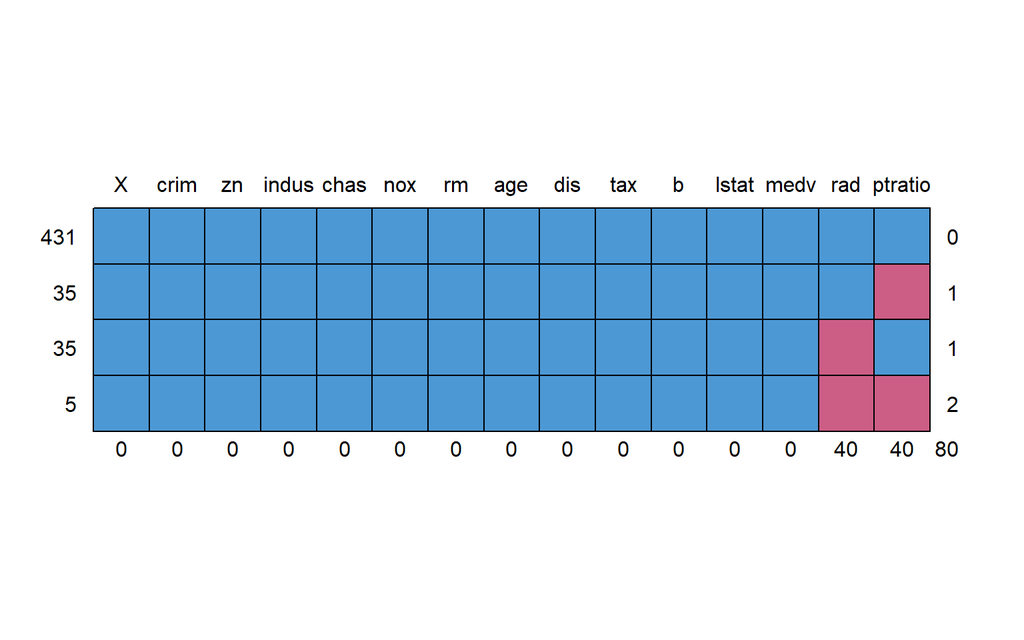

```
##     X crim zn indus chas nox rm age dis tax b lstat medv rad ptratio
## 431 1    1  1     1    1   1  1   1   1   1 1     1    1   1       1  0
## 35  1    1  1     1    1   1  1   1   1   1 1     1    1   1       0  1
## 35  1    1  1     1    1   1  1   1   1   1 1     1    1   0       1  1
## 5   1    1  1     1    1   1  1   1   1   1 1     1    1   0       0  2
##     0    0  0     0    0   0  0   0   0   0 0     0    0  40      40 80
```

```r
md.pattern(housing.data)
```

¿Como se lee esta tabla?

Tenemos 431 observaciones donde se conocen todas las variables

Hay 35 observaciones donde no se conoce a prtario

Hay 35 observaciones donde no se conoce a rad

Hay 5 observaciones donde no se conoce ptaratio ni rad

```r
#install.packages("VIM")
require(VIM)
```

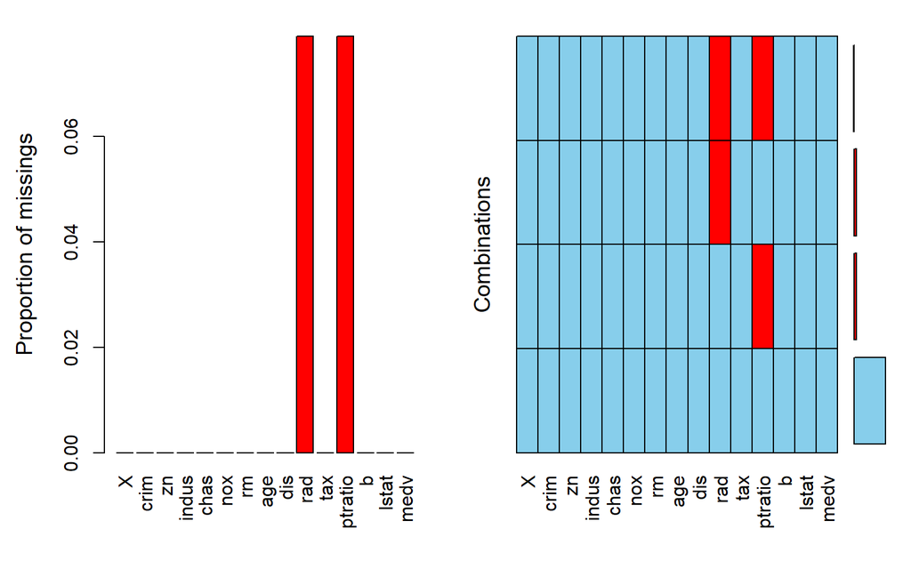

```r
aggr(housing.data)
```

Otro grafico para ver NA

La funcion aggr permite entender la informacion que falta. Se puede modificar.

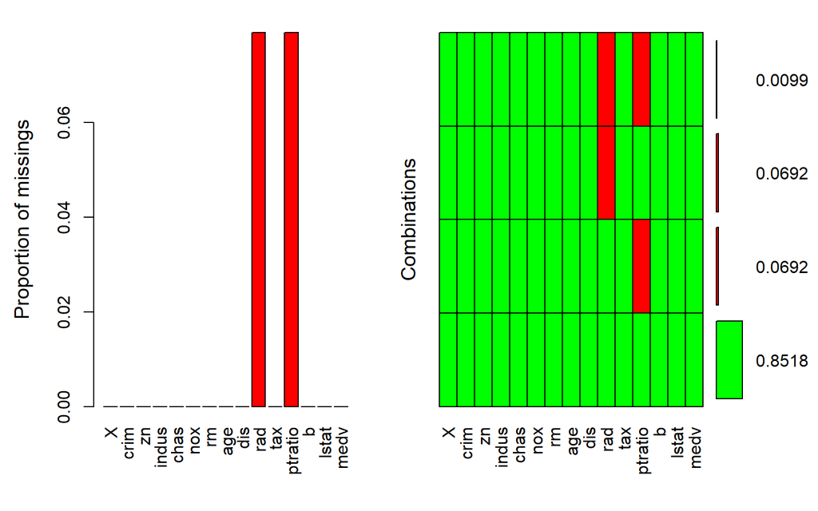

```r
aggr(housing.data, col = c("green", "red"), numbers = T)
```

Aqui estamos viendo, un porcentaje para los datos faltantes. Esto ayudaria a ver si la proporcion de NA es alta o no, si es trbajable o NO.

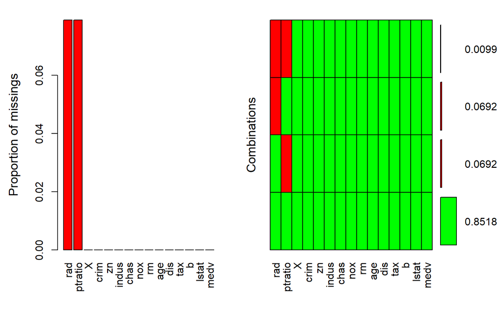

```
##
##  Variables sorted by number of missings:
##  Variable      Count
##       rad 0.07905138
##   ptratio 0.07905138
##         X 0.00000000
##      crim 0.00000000
##        zn 0.00000000
##     indus 0.00000000
##      chas 0.00000000
##       nox 0.00000000
##        rm 0.00000000
##       age 0.00000000
##       dis 0.00000000
##       tax 0.00000000
##         b 0.00000000
##     lstat 0.00000000
##      medv 0.00000000
```

```r
aggr(housing.data, col = c("green", "red"), numbers = T,
     sortVars = T,
     labels = names(housing.data))
```

Nuevamente, este es el mismo grafico pero organizado desde la que mas falta a la que menos falta

*Modificando el grafico*

Una forma de modificar ese grafico es con el parametro cex.axis que es el tamaño de la fuente

gap: parametro que modifica el huevo entre los dos graficos que se muestran. Por defecto viene en 5, vamos a moverlo. Note como esto modifica la “estrechez” del grafico.

xlab, ylab - ya c para que es

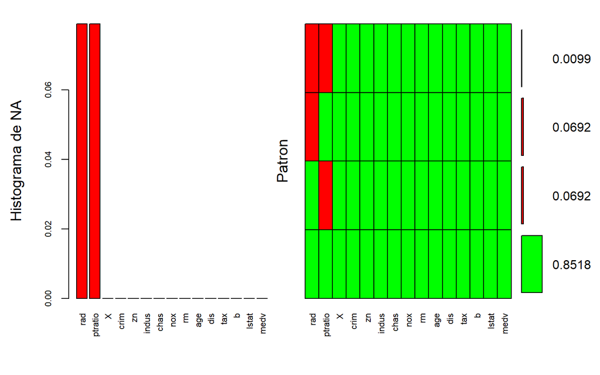

```
##
##  Variables sorted by number of missings:
##  Variable      Count
##       rad 0.07905138
##   ptratio 0.07905138
##         X 0.00000000
##      crim 0.00000000
##        zn 0.00000000
##     indus 0.00000000
##      chas 0.00000000
##       nox 0.00000000
##        rm 0.00000000
##       age 0.00000000
##       dis 0.00000000
##       tax 0.00000000
##         b 0.00000000
##     lstat 0.00000000
##      medv 0.00000000
```

```r
aggr(housing.data, col = c("green", "red"), numbers = T,
     sortVars = T,
     labels = names(housing.data),
     cex.axis = 0.7,
     gap = 2,
     ylab = c("Histograma de NA", "Patron"))
```

# Correcion de datos

## Funcion Gather

```r
require(tidyr)

crime.data <- read.csv("../data/tema1/USArrests.csv", stringsAsFactors = F)
crime.data
```

```
##                 X Murder Assault UrbanPop Rape
## 1         Alabama   13.2     236       58 21.2
## 2          Alaska   10.0     263       48 44.5
## 3         Arizona    8.1     294       80 31.0
## 4        Arkansas    8.8     190       50 19.5
## 5      California    9.0     276       91 40.6
## 6        Colorado    7.9     204       78 38.7
## 7     Connecticut    3.3     110       77 11.1
## 8        Delaware    5.9     238       72 15.8
## 9         Florida   15.4     335       80 31.9
## 10        Georgia   17.4     211       60 25.8
## 11         Hawaii    5.3      46       83 20.2
## 12          Idaho    2.6     120       54 14.2
## 13       Illinois   10.4     249       83 24.0
## 14        Indiana    7.2     113       65 21.0
```

[output cut: 36 more lines]

La funcion cbind sirve oara unir una o mas columnas al dataframe original

```r
crime.data <- cbind(state = rownames(crime.data), crime.data)
crime.data
```

```
##    state              X Murder Assault UrbanPop Rape
## 1      1        Alabama   13.2     236       58 21.2
## 2      2         Alaska   10.0     263       48 44.5
## 3      3        Arizona    8.1     294       80 31.0
## 4      4       Arkansas    8.8     190       50 19.5
## 5      5     California    9.0     276       91 40.6
## 6      6       Colorado    7.9     204       78 38.7
## 7      7    Connecticut    3.3     110       77 11.1
## 8      8       Delaware    5.9     238       72 15.8
## 9      9        Florida   15.4     335       80 31.9
## 10    10        Georgia   17.4     211       60 25.8
## 11    11         Hawaii    5.3      46       83 20.2
## 12    12          Idaho    2.6     120       54 14.2
## 13    13       Illinois   10.4     249       83 24.0
## 14    14        Indiana    7.2     113       65 21.0
```

[output cut: 36 more lines]

Se acaba de agregar una columna con los nombres de las filas. COmo las filas no tnian nombres simplemente las enumeró.

Ahora, *Vamos a unir dos variables*

```r
crime.data1 <- gather( crime.data, # dataframe de partida
                       key = "crime_type",  # nombre de la columna clave
                       value = "arrest_estimate", # nombre de la columna valor
                       Murder:UrbanPop) # nombres de las columnas a reunir
```

Lo que ha hecho esta funcion es unir

```r
crime.data2 <- gather(crime.data,
                      key = "crime_type",
                      value = "arrested_estimamte",
                      -state) # coja todas las variables menos la que le dije
```

Aqui estoy uniendo todo en unna unica columna. Mire que toda la informacion queda resumida en un unica columna de datos

```r
crime.data3 <- gather(crime.data,
                      key = "crime_type",
                      value = "arrest_estimate",
                      Murder, Assault)
```

Esta es la forma de utilizar la funcion gather.

## Funcion spread

Partir de una base de datos que ya está unida para luego separarla. Este es un paso inverso al proceso anterior.

```r
crime.data.4 <- spread(crime.data2,
                       key = "crime_type",
                       value = "arrested_estimamte")
```

## Uniendo

Mire este trucazo papa

```r
crime.data.5 <- unite(crime.data, col = "Murder_assault",
                      Murder, Assault,
                      sep ="_")
crime.data.5 %>% head
```

```
##   state          X Murder_assault UrbanPop Rape
## 1     1    Alabama       13.2_236       58 21.2
## 2     2     Alaska         10_263       48 44.5
## 3     3    Arizona        8.1_294       80 31.0
## 4     4   Arkansas        8.8_190       50 19.5
## 5     5 California          9_276       91 40.6
## 6     6   Colorado        7.9_204       78 38.7
```

basicamente cogio la base de datos original y le creo una nueva columba uniendo dos variables.

Melo.Ahora, la operacion contraria es separar una columna en dos o mas, se hace lo siguiente.

```r
crime.data.6 <- separate(crime.data.5,
                         col = "Murder_assault",
                         into= c("Muerder", "Assault"),
                         sep = "_")
crime.data.6 %>% head()
```

```
##   state          X Muerder Assault UrbanPop Rape
## 1     1    Alabama    13.2     236       58 21.2
## 2     2     Alaska      10     263       48 44.5
## 3     3    Arizona     8.1     294       80 31.0
## 4     4   Arkansas     8.8     190       50 19.5
## 5     5 California       9     276       91 40.6
## 6     6   Colorado     7.9     204       78 38.7
```

Los separamos melisimo.

# Modelos predictivos para llenar datos

Vamos a aplicar tecnicas de completacion multivariante usando modelos predictivos para rellenar los datos faltantes. Esto es lo mas GOD que podemos hacer por ahora

```r
require(mice)
housing.data <- read.csv("../data/tema1/housing-with-missing-value.csv",
                         header = T,
                         stringsAsFactors = F)

columns <- c("ptratio", "rad") # las columnas con problemas de NA

imputed_data <- mice(housing.data[,names(housing.data)%in% columns],
                     seed = 2018,
                     m = 5,# 5 valores diferentes de cd iteracion
                     maxit = 50, # 50 iteracioes
                     method = "pmm")  #predicted mean matched, existen 4
# pmm - comparacion predictiva de medias
# logreg - regresion logistica
# polyreg - regresion logistica polinomial
# polr - modelo de probabilidades proporcionales
```

Esto de aca es solo el modelo. Hay que usarlo para predecir los valores faltantes

```r
imputed_data %>% summary()
```

```
## Class: mids
## Number of multiple imputations:  5
## Imputation methods:
##     rad ptratio
##   "pmm"   "pmm"
## PredictorMatrix:
##         rad ptratio
## rad       0       1
## ptratio   1       0
```

Entonces se va a usar el modelo para completar los datos faltantees

```r
complete.data <- complete(imputed_data)
housing.data$ptratio <- complete.data$ptrario
housing.data$rad <- complete.data$rad
```

```r
anyNA(housing.data) # No Hay un NA
```

```
## [1] FALSE
```

## Otra fomrma

```r
housing.data <- read.csv("../data/tema1/housing-with-missing-value.csv",
                         header = T,
                         stringsAsFactors = F)
impute_arg <- aregImpute(~ptratio+rad, data = housing.data,
                          n.impute = 5)
```

```
## Iteration 1
Iteration 2
Iteration 3
Iteration 4
Iteration 5
Iteration 6
Iteration 7
Iteration 8
```

Note que ahora esto es un modelo

```r
impute_arg
```

```
##
## Multiple Imputation using Bootstrap and PMM
##
## aregImpute(formula = ~ptratio + rad, data = housing.data, n.impute = 5)
##
## n: 506   p: 2    Imputations: 5      nk: 3
##
## Number of NAs:
## ptratio     rad
##      40      40
##
##         type d.f.
## ptratio    s    2
## rad        s    1
##
## Transformation of Target Variables Forced to be Linear
##
## R-squares for Predicting Non-Missing Values for Each Variable
## Using Last Imputations of Predictors
## ptratio     rad
##   0.231   0.326
```

Note que ahora con el R cuadrado puedo mirar que tan buena es la prediccion de los NA.

Recuerde, se desea un R cuadrado cercano a uno

```r
impute_arg$imputed$rad
```

```
##     [,1] [,2] [,3] [,4] [,5]
## 29     4    4    4    4    4
## 61     6    5    2    4    4
## 83     4    3    4    4    4
## 85     4    3    4    4    4
## 101    1    5    4    5    4
## 131    4    4    4    4    4
## 133    4    5    4    4    4
## 139    4    4    4    4    4
## 156   24    4    2    1    5
## 166    4    5    5    5    5
## 175    3    6    1    4    5
## 176    1    1    5    5    5
## 185    3    8    4    5    8
## 197    6    4    1    4    4
```

[output cut: 26 more lines]

Estas son las posibles tablas con los valores NA que se desean rellenar.

# Deteccion de outliers

```r
ozone.data <- read.csv("../data/tema1/ozone.csv",
                       stringsAsFactors = F)
```

Vamos a intentar detectar putliers

Empecemos con la presion heigh para mirarm

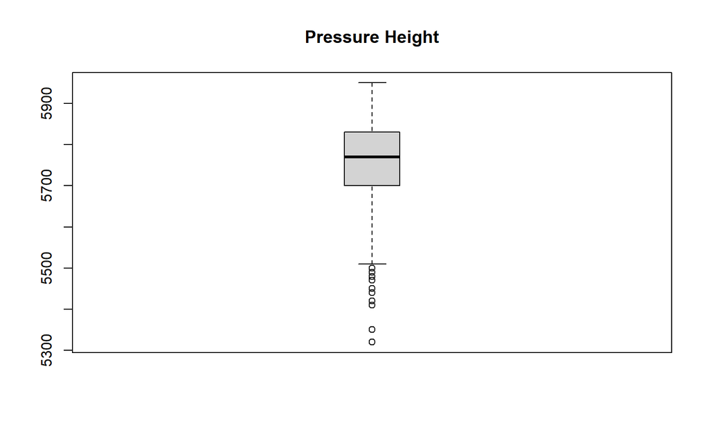

```r
outliers_values <- ozone.data$pressure_height %>% boxplot(main = "Pressure Height", boxwex = 0.2)
```

Interpretacion de toda la vida de boxplot

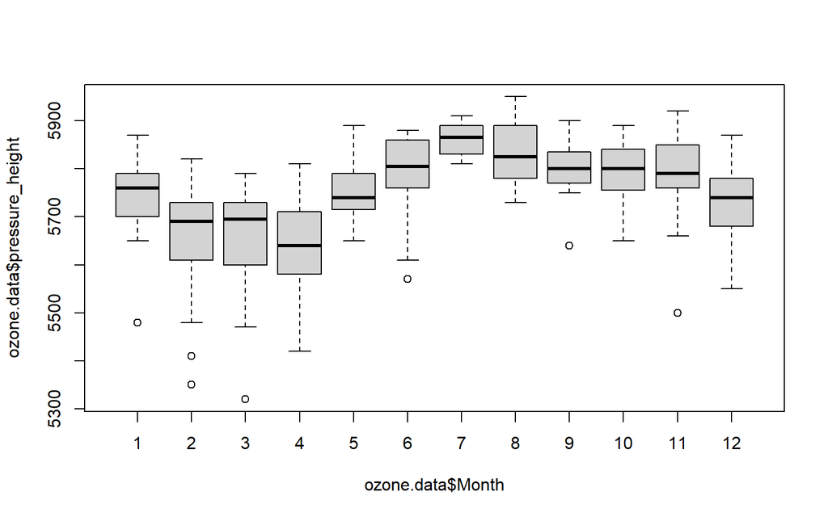

```r
boxplot(ozone.data$pressure_height ~ ozone.data$Month)
```

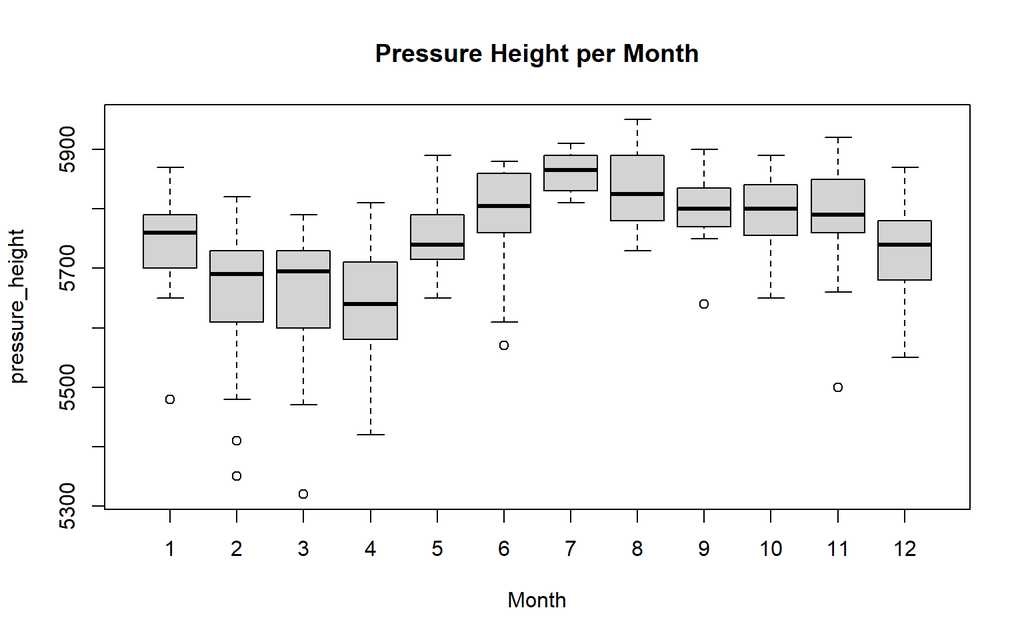

```r
boxplot(pressure_height ~ Month,
        data = ozone.data,
        main = "Pressure Height per Month")
```

en general, buscamos lo que esté fuera de las cajas

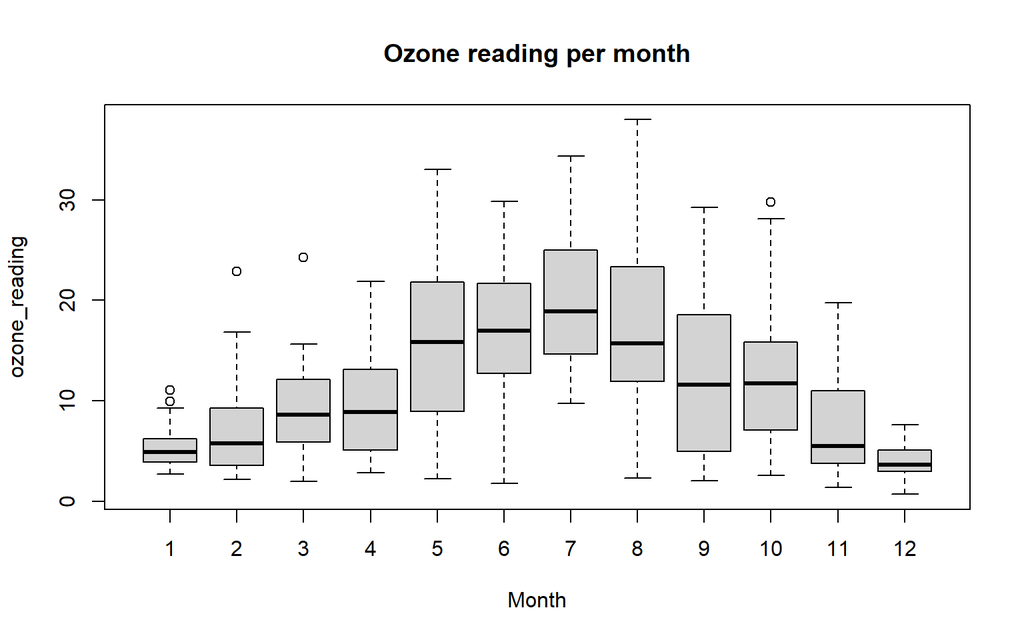

```r
boxplot(ozone_reading ~ Month,
        data =  ozone.data,
        main = "Ozone reading per month")
```

De manera general siempre buscamos tener con los boxplots los outliers a la manos.

```r
boxplot( ozone.data$pressure_height ,main = "Pressure Height", boxwex = 0.2)$out
```

```
##  [1] 5480 5410 5350 5480 5490 5470 5320 5420 5440 5480 5450 5500
```

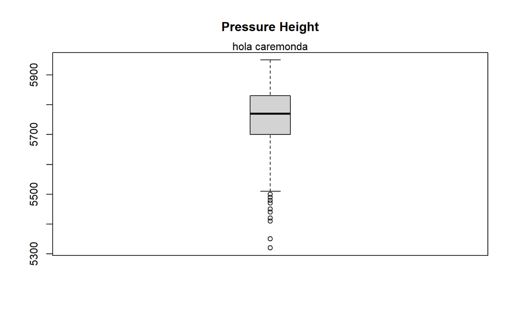

```r
mtext("hola caremonda")
```

Mire que ahora en consola tengo los outliers